# Overview of ggDoE

The *ggDoE* package provides an easy approach to creating commonly used graphs in Design of Experiments with the R package *ggplot2*. The following plots are currently available in *ggDoE*:

1. Alias Matrix
2. Box-Cox Transformation
3. Lambda Plot
4. Boxplots
5. Regression Diagnostic Plots
6. Half-Normal Plot
7. Interaction Effects Plot for a Factorial Design
8. Main Effects Plot for a Factorial Design
9. Contour Plots for Response Surface Methodology
10. Pareto Plot
11. Two Dimensional Projections of a Latin Hypercube Design

The following datasets/designs are included in *ggDoE* as tibbles:

- **adapted_epitaxial**: Adapted epitaxial layer experiment obtain from the book  
  *“Experiments: Planning, Analysis, and Optimization, 2nd Edition”*

```r
ggDoE::adapted_epitaxial
```

```
#> # A tibble: 16 × 7
#>        A     B     C     D  ybar    s2  lns2
#>    <dbl> <dbl> <dbl> <dbl> <dbl> <dbl> <dbl>
#>  1    -1    -1    -1     1  14.6 0.270 -1.31
#>  2    -1    -1    -1    -1  13.6 0.291 -1.23
#>  3    -1    -1     1     1  14.2 0.268 -1.32
#>  4    -1    -1     1    -1  14.0 0.197 -1.62
#>  5    -1     1    -1     1  14.6 0.221 -1.51
#>  6    -1     1    -1    -1  13.9 0.205 -1.59
#>  7    -1     1     1     1  14.4 0.222 -1.51
#>  8    -1     1     1    -1  14.1 0.215 -1.54
#>  9     1    -1    -1     1  14.7 0.269 -1.31
#> 10     1    -1    -1    -1  13.7 0.272 -1.30
#> 11     1    -1     1     1  13.8 0.220 -1.51
#> 12     1    -1     1    -1  13.9 0.229 -1.47
#> 13     1     1    -1     1  14.6 0.227 -1.48
#> 14     1     1    -1    -1  13.9 0.253 -1.37
#> 15     1     1     1     1  14.3 0.250 -1.39
#> 16     1     1     1    -1  14.1 0.192 -1.65
```

- **original_epitaxial**: Original epitaxial layer experiment obtain from the book  
  *“Experiments: Planning, Analysis, and Optimization, 2nd Edition”*

```r
ggDoE::original_epitaxial
```

```
#> # A tibble: 16 × 7
#>        A     B     C     D  ybar       s2  lns2
#>    <dbl> <dbl> <dbl> <dbl> <dbl>    <dbl> <dbl>
#>  1    -1    -1    -1     1  14.8 0.00312  -5.77
#>  2    -1    -1    -1    -1  13.9 0.00494  -5.31
#>  3    -1    -1     1     1  14.8 0.00333  -5.70
#>  4    -1    -1     1    -1  13.9 0.000926 -6.98
#>  5    -1     1    -1     1  14.9 0.00269  -5.92
#>  6    -1     1    -1    -1  14.2 0.00415  -5.48
#>  7    -1     1     1     1  14.9 0.0165   -4.11
#>  8    -1     1     1    -1  14.0 0.00196  -6.24
#>  9     1    -1    -1     1  14.9 0.215    -1.54
#> 10     1    -1    -1    -1  14.0 0.121    -2.12
#> 11     1    -1     1     1  14.4 0.206    -1.58
#> 12     1    -1     1    -1  13.9 0.226    -1.49
#> 13     1     1    -1     1  14.9 0.147    -1.92
#> 14     1     1    -1    -1  14.0 0.0880   -2.43
#> 15     1     1     1     1  14.8 0.327    -1.12
#> 16     1     1     1    -1  13.9 0.0704   -2.65
```

- **aliased_design**: D-efficient minimal aliasing design obtained from the article  
  *“Efficient Designs With Minimal Aliasing”*

```r
ggDoE::aliased_design
```

```
#> # A tibble: 12 × 5
#>        A     B     C     D     E
#>    <dbl> <dbl> <dbl> <dbl> <dbl>
#>  1    -1     1    -1     1     1
#>  2    -1     1     1     1    -1
#>  3    -1    -1     1    -1     1
#>  4     1     1     1     1     1
#>  5     1     1     1    -1    -1
#>  6     1    -1    -1     1    -1
#>  7    -1     1    -1    -1     1
#>  8     1    -1     1     1     1
#>  9     1     1    -1    -1    -1
#> 10    -1    -1     1    -1    -1
#> 11     1    -1    -1    -1     1
#> 12    -1    -1    -1     1    -1
```

```r
library(ggDoE)
```

## Alias Matrix

Let $X_1$ denote the model matrix for the main-effects model (including the intercept) and let $X_2$ denote the model matrix corresponding to the two-factor interactions.

Suppose the true model is
$$Y = X_1 \beta_1 + X_2 \beta_2 + \epsilon$$
where $\epsilon$ is the vector of residuals with $\mathbb{E}(\epsilon)=0$, $\beta_1$ is the vector consisting of the intercept and main effects coefficients and $\beta_2$ is the vector consisting of the two-factor interactions effects coefficients.

If the experimenter employs the main effects model for estimation, it is well known that the expected value of the least squares estimator $\hat{\beta}_1$ of $\beta_1$ is

$$\mathbb{E}(\hat{\beta}_1) = \beta_1 + A \beta_2$$
where $A$ is the *alias matrix*.

We define the *alias matrix* $A$ by
$$A = (X_1^T \, X_1)^{-1} \ X_1^T X_2$$

One can view the color map of the absolute value of the correlations among the main effects and two-factor interaction columns using the function `alias_matrix()`

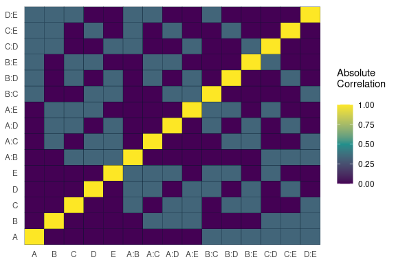

```r
alias_matrix(design=aliased_design)
```

For *most* functions in *ggDoE* one can choose to not display the plot and only return the data/calculations used to construct the plot by using `showplot=FALSE` argument. For example, we can simply return the correlation matrix *(not absolute)* among the main effects and two-factor interactions as follows

```r
alias_matrix(design=aliased_design, showplot=FALSE)
```

```
#>      A:B   A:C    A:D    A:E    B:C    B:D    B:E   C:D    C:E   D:E
#> A  0.000 0.000  0.000  0.000  0.333 -0.333 -0.333 0.333  0.333 0.333
#> B  0.000 0.333 -0.333 -0.333  0.000  0.000  0.000 0.333 -0.333 0.333
#> C  0.333 0.000  0.333  0.333  0.000  0.333 -0.333 0.000  0.000 0.333
#> D -0.333 0.333  0.000  0.333  0.333  0.000  0.333 0.000  0.333 0.000
#> E -0.333 0.333  0.333  0.000 -0.333  0.333  0.000 0.333  0.000 0.000
```

## Box-Cox Transformation

Box-Cox transformation is a transformation of a response variable that often is not normally distributed, to one that does follow approximately a normal distribution. The transformation performed is as follows

$$y(\lambda) =
\begin{cases}
\frac{y^\lambda -1}{\lambda}, & \text{if} \, \lambda \neq 0 \\
\log y, & \text{if} \, \lambda =0
\end{cases}$$

The “optimal value” of $\lambda$ is one which results in the best approximation of a normal distribution curve.

Some common Box-Cox transformations are

| $\lambda$ | $y(\lambda)$ |
| --- | --- |
| -2 | $\frac{1}{y^2}$ |
| -1 | $\frac{1}{y}$ |
| -$\frac{1}{2}$ | $\frac{1}{\sqrt{y}}$ |
| 0 | $\log y$ |
| $\frac{1}{2}$ | $\sqrt{y}$ |
| 1 | $y$ |
| 2 | $y^2$ |

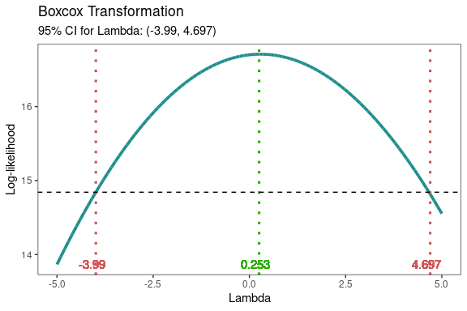

```r
model <- lm(s2 ~ (A+B+C+D),data = adapted_epitaxial)
boxcox_transform(model,lambda = seq(-5,5,0.2))
```

From the above figure, the “optimal value” of $\lambda=0.253$. A good transformation to perform would then be $\log(y)$. The results can be extracted by using `showplot=FALSE` argument, if needed.

```r
boxcox_transform(model,lambda = seq(-5,5,0.2),
                 showplot = FALSE)
```

```
#> # A tibble: 1 × 3
#>   best_lambda lambda_low lambda_high
#>         <dbl>      <dbl>       <dbl>
#> 1       0.253      -3.99        4.70
```

The transformation doesn’t always work well, so make sure to check the diagnostics of the model with the transformed response. See `diagnostic_plots()`.

## Lambda Plot

Obtain the trace plot of the *t*-statistics calculated for each effect in the model after applying Box-Cox transformation across a specified sequence of lambda values

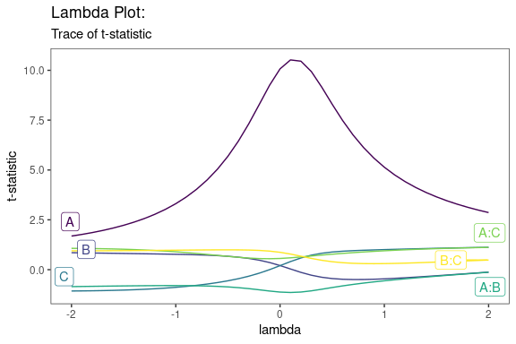

```r
model <-  lm(s2 ~ (A+B+C)^2,data=original_epitaxial)
lambda_plot(model)
```

or alternatively,

```r
lambda_plot(model, showplot=FALSE)
```

```
#> # A tibble: 41 × 7
#>    lambda     A     B      C  `A:B` `A:C` `B:C`
#>     <dbl> <dbl> <dbl>  <dbl>  <dbl> <dbl> <dbl>
#>  1   -2    1.69 0.850 -1.07  -0.851 1.07  0.945
#>  2   -1.9  1.77 0.843 -1.07  -0.844 1.07  0.946
#>  3   -1.8  1.86 0.835 -1.06  -0.837 1.06  0.947
#>  4   -1.7  1.97 0.828 -1.05  -0.830 1.05  0.949
#>  5   -1.6  2.09 0.820 -1.04  -0.823 1.04  0.951
#>  6   -1.5  2.23 0.813 -1.02  -0.816 1.03  0.954
#>  7   -1.4  2.38 0.805 -1.01  -0.811 1.01  0.958
#>  8   -1.3  2.57 0.797 -0.984 -0.806 0.986 0.962
#>  9   -1.2  2.78 0.789 -0.957 -0.802 0.961 0.966
#> 10   -1.1  3.02 0.780 -0.925 -0.800 0.931 0.971
#> # … with 31 more rows
```

## Boxplots

```r
data <- ToothGrowth
data$dose <- factor(data$dose,levels = c(0.5, 1, 2),
                    labels = c("D0.5", "D1", "D2"))
```

```r
head(data)
```

```
#>    len supp dose
#> 1  4.2   VC D0.5
#> 2 11.5   VC D0.5
#> 3  7.3   VC D0.5
#> 4  5.8   VC D0.5
#> 5  6.4   VC D0.5
#> 6 10.0   VC D0.5
```

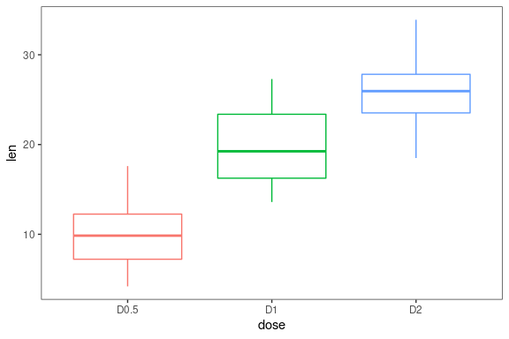

```r
gg_boxplots(data,response = 'len',
            factor = 'dose')
```

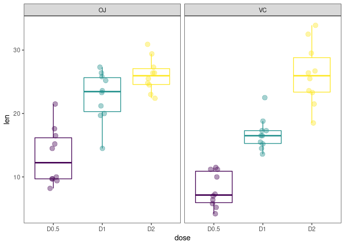

```r
gg_boxplots(data,response = 'len',
            factor = 'dose',
            group_var = 'supp',
            color_palette = 'viridis',
            jitter_points = TRUE)
```

## Regression Diagnostic Plots

1. Residual vs. Fitted Values
2. Normal-QQ plot
3. Scale-Location plot
4. Residual vs. Leverage
5. Cook’s Distance
6. Collinearity

```r
model <- lm(mpg ~ wt + am + gear + vs * cyl, data = mtcars)
```

The default plots in `diagnostic_plots()` are the first four in the list mentioned above. However, one can choose any of the six plots they need. For example if one needs all six plots use `which_plots=1:6`.

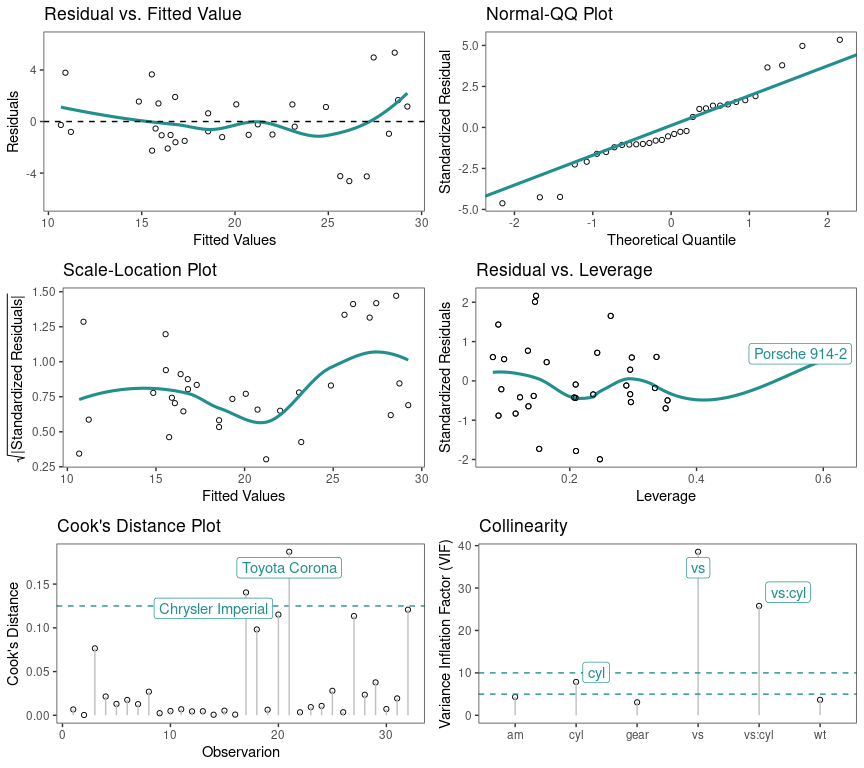

```r
diagnostic_plots(model, which_plots=1:6)
```

Another example, if one simply requires the Residual vs. Fitted Values and Cook’s Distance plots, use `which_plots = c(1,5)`. If one wants to display confidence intervals, use `standard_error=TRUE`

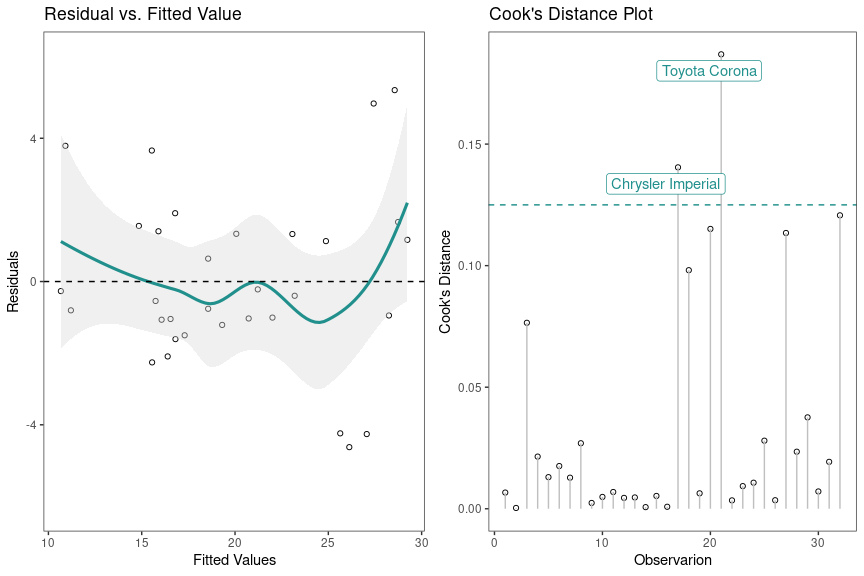

```r
diagnostic_plots(model, which_plots=c(1,5),
                 standard_errors = TRUE)
```

## Half-Normal Plot

The Half-Normal plot is a graphical tool used to help identify which experiment factors have significant effects on the response. In addition, cutoff line(s) are added for the margin of error (ME) and the simultaneous margin of error (SME) of the effects. These values are obtained using `unrepx::ME()`.

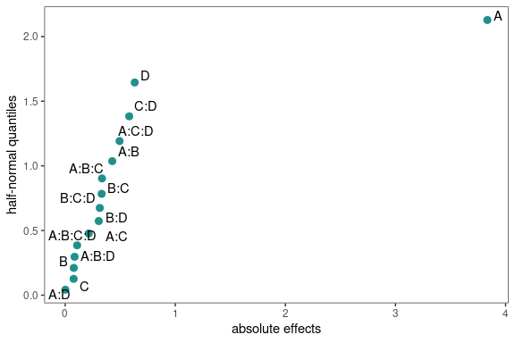

```r
m1 <- lm(lns2 ~ (A+B+C+D)^4,data=original_epitaxial)
half_normal(m1)
```

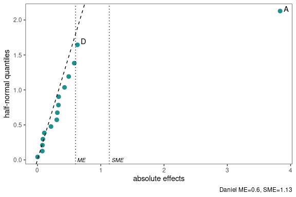

```r
half_normal(m1,method='Daniel',alpha=0.1,
            ref_line=TRUE,label_active=TRUE,
            margin_errors=TRUE)
```

You can change the significance level used to obtain (ME) and (SME) and determine which factors are active using the `alpha` argument. Default is `alpha=0.05`. Using `label_active` argument will only label the active factors in the experiment.

Using `showplot=FALSE` will return the needed information to reproduce/change the above half-normal plot

```r
half_normal(m1,method='Daniel',alpha=0.1,
            showplot=FALSE)
```

```
#> # A tibble: 15 × 3
#>    effects absolute_effects half_normal_quantiles
#>    <chr>              <dbl>                 <dbl>
#>  1 A:D              0.00197                0.0418
#>  2 C                0.0768                 0.126
#>  3 B                0.0783                 0.210
#>  4 A:B:D            0.0858                 0.297
#>  5 A:B:C:D          0.109                  0.385
#>  6 A:C              0.214                  0.477
#>  7 B:D              0.305                  0.573
#>  8 B:C:D            0.314                  0.674
#>  9 B:C              0.331                  0.784
#> 10 A:B:C            0.335                  0.903
#> 11 A:B              0.428                  1.04
#> 12 A:C:D            0.494                  1.19
#> 13 C:D              0.582                  1.38
#> 14 D                0.632                  1.64
#> 15 A                3.83                   2.13
```

## Interaction Effects Plot for a Factorial Design

Interaction effects plot between two factors in a factorial design

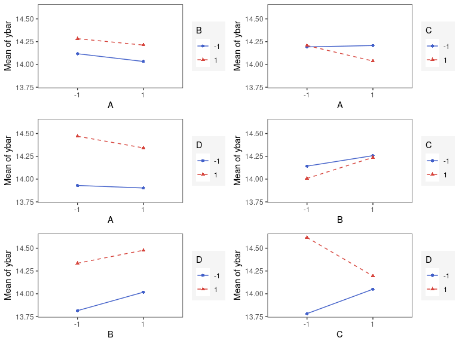

```r
interaction_effects(adapted_epitaxial,response = 'ybar',
                    exclude_vars = c('s2','lns2'))
```

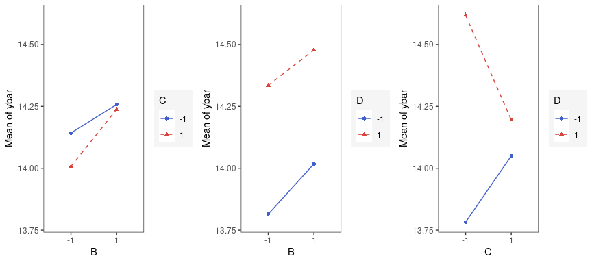

```r
interaction_effects(adapted_epitaxial,response = 'ybar',
                    exclude_vars = c('A','s2','lns2'),
                    n_columns=3)
```

## Main Effects Plot for a Factorial Design

Main effect plots for each factor in a factorial design

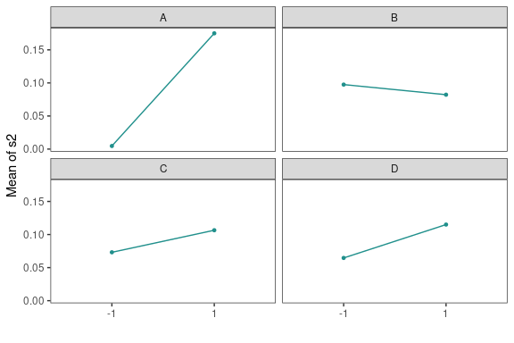

```r
main_effects(original_epitaxial,
             response='s2',
             exclude_vars = c('ybar','lns2'))
```

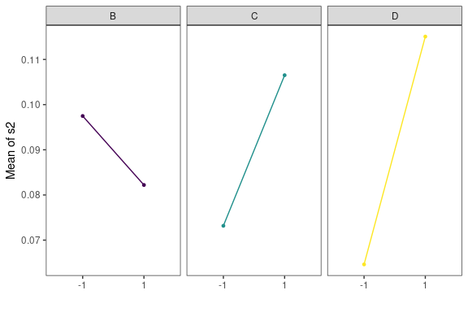

```r
main_effects(original_epitaxial,
             response='s2',
             exclude_vars = c('A','ybar','lns2'),
             color_palette = 'viridis',
             n_columns=3)
```

## Contour Plots for Response Surface Methodology

```r
heli.rsm <- rsm::rsm(ave ~ SO(x1, x2, x3, x4),
                     data = rsm::heli)
```

Using `gg_rsm` we can obtain contour plots that display the fitted surface for an `rsm` object. It is best to use `rsm` object such as the one defined above, as the plots below are produced using information from an `rsm` object. `gg_rsm` includes an `...` argument for additional arguments from `rsm::contour.lm`, see `rsm::contour.lm` for more details on its arguments.

By default the contour plots produce will be in black and white color

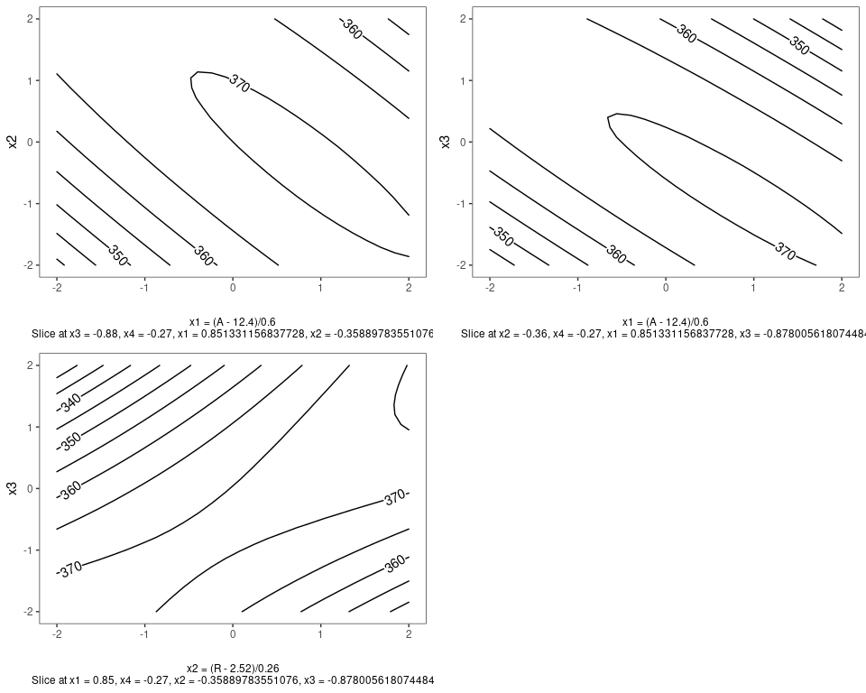

```r
gg_rsm(heli.rsm,form = ~x1+x2+x3,
       at = rsm::xs(heli.rsm),
       n_columns=2)
```

with `filled=TRUE`, a viridis color scheme is applied.

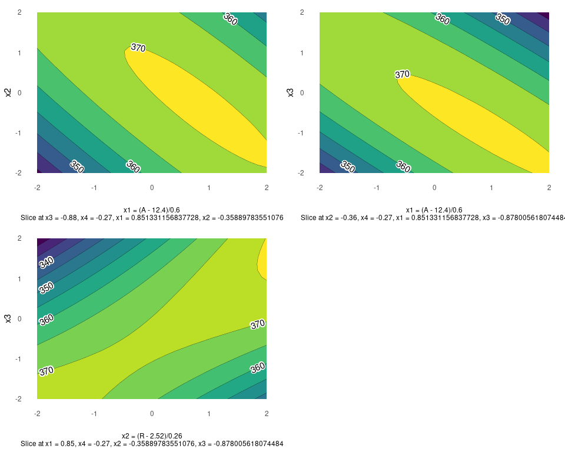

```r
gg_rsm(heli.rsm,form = ~x1+x2+x3,
       at = rsm::xs(heli.rsm),
       filled = TRUE,
       n_columns=2)
```

## Pareto Plot

Pareto plot is a bar graph with the bars ordered by the size of the effect. In addition, cutoff line(s) are added for the margin of error (ME) and the simultaneous margin of error (SME) of the effects.

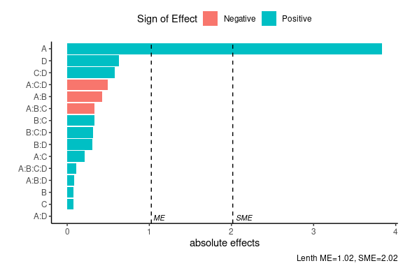

```r
m1 <- lm(lns2 ~ (A+B+C+D)^4,data=original_epitaxial)
pareto_plot(m1)
```

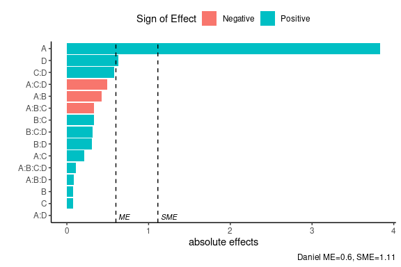

```r
pareto_plot(m1,method='Daniel',alpha=0.1)
```

If one uses the `showplot=FALSE` argument, a list will be returned with the calculated PSE,ME,SME as well as the data used to construct the pareto plot.

```r
pareto_plot(m1,method='Daniel',
            alpha=0.1, showplot=FALSE)
```

```
#> $errors
#> # A tibble: 1 × 4
#>   alpha   PSE    ME   SME
#>   <dbl> <dbl> <dbl> <dbl>
#> 1   0.1 0.335 0.600  1.11
#>
#> $dat
#> # A tibble: 15 × 3
#>    effect_names  effects abs_effects
#>    <fct>           <dbl>       <dbl>
#>  1 A:D           0.00197     0.00197
#>  2 C             0.0768      0.0768
#>  3 B             0.0783      0.0783
#>  4 A:B:D         0.0858      0.0858
#>  5 A:B:C:D       0.109       0.109
#>  6 A:C           0.214       0.214
#>  7 B:D           0.305       0.305
#>  8 B:C:D         0.314       0.314
#>  9 B:C           0.331       0.331
#> 10 A:B:C        -0.335       0.335
#> 11 A:B          -0.428       0.428
#> 12 A:C:D        -0.494       0.494
#> 13 C:D           0.582       0.582
#> 14 D             0.632       0.632
#> 15 A             3.83        3.83
```

## Two Dimensional Projections

This function will output all two dimensional projections from a Latin hypercube design.

Below is an example from generating a random Latin hypercube design using the R package `lhs`

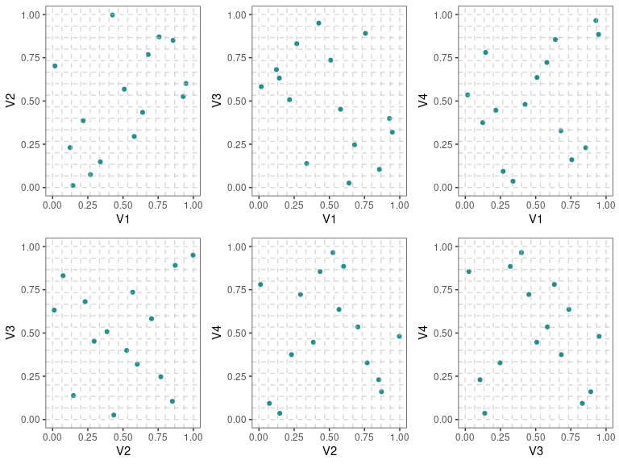

```r
set.seed(10)
random_LHS <- lhs::randomLHS(n=15, k=4)
twoD_projections(random_LHS,n_columns=3,grid = TRUE)
```

Below is an example of a maximin Latin hypercube design with red color points and no grid (default setting)

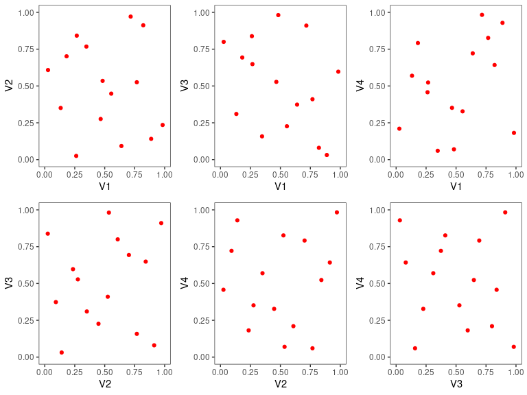

```r
maximin_LHS <- lhs::maximinLHS(n=15, k=4)
twoD_projections(maximin_LHS,n_columns=3,point_color = 'red')
```